###### Virtualisation et Cloud - © TEK-UP University

# LAB04 : Docker

### Objectif

- L’objectif de ce TP est de se familiariser avec la construction des images Docker.
  - Dans une première phase, l'application sera crée, hébergée et démarrée sur la machine hôte (application classique).
  - Dans une deuxième phase, on va créer une image de l'application à partir du fichier Dockerfile : utilisation de la commande "docker build".
  - Dans une troisième phase, on va créer une image de l'application à partir d'un conteneur : utilisation de la commande "docker commit".

###### Prérequis

- Système Linux avec Docker installé.

# Construction d'une image Docker "Hello"

## Développement d'une application "hello" sur la machine locale

1- Créez un répertoire "hello_directory" qui va contenir votre dockerfile.

```python
$ mkdir hello_directory
$ cd hello_directory
```

2- Dans le répertoire hello, créez un fichier "hello.c" qui permet d’afficher le message "Hello From Docker LAB !".

```python
$ nano hello.c
```

```python
#include <stdio.h>
int main()
{
   printf("Hello From Docker LAB !  \n");
    return 0;

}
```

3- Compilez le code source (hello.c) avec gcc en créant le fichier exécutable "hello"

```python
$ gcc -o hello -static hello.c
```

**- L'option "static" est ajoutée pour creér un fichier exécutable statique sans dépendances logicielles. En d'autres termes, il ne nécessite pas de dépendance sur les bibliothèques dynamiques au moment de l'exécution de la commande.**

4- Affichez le contenu du dossier hello après compilation : un fichier exécutable "hello" s'est ajouté après compilation (fichier objet).

```python
$ ls
hello  hello.c
```

5- Exécutez le fichier "hello"

```python
$ ./hello
```

```python
## Résultat
Hello From Docker LAB !
```

## Création d'une image Docker "hello" à partir du fichier Dockerfile : command "docker build"

### Méthode 1 : image de base "ubuntu"

- Pour éditer le fichier Dockerfile en partant d'un système de fichiers "ubuntu", on doit enchainer avec ces actions :
  - Installer le compilateur gcc
  - Copier le code source "hello.c" sur le système de fichiers image
  - Compiler le fichier code source
  - Exécuter la commande "/hello"

###### Etape 1 : Préparation du fichier Dockerfile

1- Tapez la commande suivante pour créer et éditer le fichier "Dockerfile" :

```python
$ nano Dockerfile
```

2- Ecrivez les lignes de code suivante sur le fichier Dockerfile.

```python
FROM ubuntu
RUN apt-get -y update
RUN apt-get -y install gcc
COPY hello.c /
RUN gcc -o hello hello.c
CMD ["/hello"]
```

###### Etape 2 : Création image avec la commande "docker build"

3- Créez une image nommée hello:version1 à partir du Dockerfile. - Noubliez pas d'ajouter le point en fin de ligne pour indiquer le chemin d'accès du fichier Dockerfile.

```python
$ docker build -t hello:version1 .
```

4- Vérifiez que l'image est crée

```python
$ docker images
```

```python
## Résultat
~/hello_directory$ docker images
REPOSITORY    TAG        IMAGE ID       CREATED         SIZE
hello   version1   bbd500eb2345   5 seconds ago   251MB
ubuntu        latest     ba6acccedd29   12 days ago     72.8MB
```

**Etape 3 : Exécution d'un conteneur à partir de l'image "hello"**

5- Créer et démarrer un conteneur qui utilise l'image "hello"

```python
$ docker run hello:version1
```

```python
#Résultat
~/hello_directory$ docker run hello:version1
Hello From Docker LAB !
```

### Méthode 2 : image de base "machine vide : scratch"

- On peut utiliser directement le fichier objet "hello" déjà généré pour la construction de l'image.
  - Ce fichier ne nécessite aucun système de fichiers de base pour s'exécuter : aucune dépendance
  - L'image de base est ainsi la machine vide : scratch

###### Etape 1 : Préparation du fichier Dockerfile

1- Tapez la commande suivante pour créer et éditer le fichier "Dockerfile" :

```python
$ nano Dockerfile
```

2- Ecrivez les lignes de code suivante sur le fichier Dockerfile.

```python
FROM scratch
COPY hello /
CMD ["/hello"]
```

###### Etape 2 : Création image avec la commande "docker build"

3- Créez une image nommée hello:version2 à partir du Dockerfile. - Noubliez pas d'ajouter le point en fin de ligne pour indiquer le chemin d'accès du fichier Dockerfile.

```python
$ docker build -t hello:version2 .
```

4- Vérifiez que l'image est crée

```python
$ docker images
```

```python
## Résultat
~/hello$ docker images
REPOSITORY    TAG        IMAGE ID       CREATED          SIZE
hello   version2   c32e701ce11c   8 seconds ago    845kB
hello   version1   bbd500eb2345   42 minutes ago   251MB
ubuntu        latest     ba6acccedd29   12 days ago      72.8MB
```

**Etape 3 : Exécution d'un conteneur à partir de l'image "hello"**

5- Créer et démarrer un conteneur qui utilise l'image "hello"

```python
$ docker run hello:version2
```

```python
#Résultat
~/hello_directory$ docker run hello:version2
Hello From Docker LAB !
```

## Création d'une image Docker "hello" à partir d'un conteneur : commande "docker commit"

- Dans cette partie, on va créer l'application précédante à partir d'un conteneur ubuntu.

###### Suppression de l'application locale

- Supprimez le répertoire de travail de votre application.

```python
$ cd
$ rm -r hello_directory
```

###### Etape 1 : Création et démarrage d'un conteneur Docker

1- Créez un nouveau conteneur Docker à partir de l'image "ubuntu" en mode intéractif et nommez le "hello_container"

```python
$ docker create -it --name hello_container ubuntu
```

2- Démarrez votre conteneur

```python
$ docker start hello_container
```

###### Etape 2 : Modification du conteneur-Installation de gcc

3- Faites l'accès à votre conteneur en ouvrant une session bash :

```python
$ docker exec -it hello_container /bin/bash
```

4- Mettez à jour la liste des packages :

```python
apt update
```

5- Installez gcc :

```python
apt install gcc
```

###### Etape 3 : Création de l'application

6- Créez un répertoire "hello_directory" qui va contenir votre dockerfile.

```python
mkdir hello_directory
cd hello_directory
```

7- Dans le répertoire hello, créez un fichier "hello.c" qui permet d’afficher le message "Hello From Docker LAB !".

**Remarque :** Si la commande "nano" est non reconnue, installez "nano"

```python
apt install nano
```

```python
nano hello.c
```

```python
#include <stdio.h>
int main()
{
   printf("Hello From Docker LAB !  \n");
    return 0;

}
```

8- Compilez le code source (hello.c) avec gcc en créant le fichier exécutable "hello"

```python
$ gcc -o hello hello.c
```

9- Exécutez le fichier "hello"

```python
$ ./hello
```

```python
## Résultat
Hello From Docker LAB !
```

10- Quittez le conteneur :

```python
exit
```

###### Etape 4 : Enregistrement des modifications apportées au conteneur à une image- La commande docker commit

11- Pour enregistrer les modifications apportées sur votre conteneur d'une façon permanente, Créez une image nommée "hello:version3" à partir du conteneur "hello_container"

```python
$ docker commit hello_container hello:version3
```

12- Vérifiez que l'image est crée

```python
$ docker images
```

```python
$ docker images
REPOSITORY    TAG        IMAGE ID       CREATED          SIZE
hello  version3   c54c94914fe1   8 seconds ago    252MB
hello  version2   c32e701ce11c   50 minutes ago   845kB
hello  version1   bbd500eb2345   2 hours ago      251MB
ubuntu        latest     ba6acccedd29   12 days ago      72.8MB
```

###### Etape 5 : Exécution de l'image sur un conteneur

13- L’étape suivante est d’instancier depuis cette image un conteneur.

- Remarque : pour lancer l'applcation et afficher le message d'accueil, on doit passerla commande "/hello_directory/hello" au moment de lancement du conteneur

```python
$ docker run  hello:version3 /hello_directory/hello
```

## Conclusion

1- Affichez la liste des images disponibles dans le dépôt local Docker et comparez la taille des trois versions de l'image "hello".

```python
$ docker images
```

[figure not shown]

2- Interprétez le résultat.

# Publication de l'image

- Pour avoir la possibilité de publier votre image dans le registre Docker Hub, vous devez créer votre propre compte sur le lien https://hub.docker.com/.

###### Etape 1 : Docker Hub login

1- Une fois votre compte a été créé, vous pouvez vous connecter à partir du terminal en exécutant la commande suivante :

```python
$ docker login
```

```python
$ docker login
Login with your Docker ID to push and pull images from Docker Hub. If you don't have a Docker ID, head over to https://hub.docker.com to create one.
Username: <your_name>
Password:
WARNING! Your password will be stored unencrypted in /home/ubuntu/.docker/config.json.
Configure a credential helper to remove this warning. See
https://docs.docker.com/engine/reference/commandline/login/#credentials-store

Login Succeeded
```

###### Etape 2 : Ajout d'une TAG à l'image

2- Récupérez l’ID de votre image.

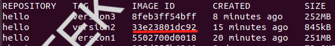

3- Ajoutez le tag "latest" à votre image :

```python
$ docker tag 33e23801dc92 <your_name>/hello:latest
```

4- Publiez votre image avec la commande :

```python
$ docker push <your_name>/hello:latest
```

5- Visitez https://hub.docker.com/ et consultez votre image.

###### Virtualisation et Cloud - © TEK-UP University